# Pluralsight Model Building Take-Home

William Rinauto

2022-03-23

```r
library(tidyverse)
library(h2o)
library(vtable)
library(scales)
library(ggcorrplot)
library(kableExtra)
library(rpart)
library(rpart.plot)
```

```r
training_dat <- read.csv('recruiting_zeta-disease_training-data_take-home-challenge - 2021_zeta-disease_training-data_take-home-challenge.csv')
predict_these <- read.csv('recruiting_zeta-disease_prediction-data_take-home-challenge - 2021-01-21_zeta-disease_prediction-data_take-home-challenge.csv')

#Check for duplicate rows.
#Even though there is no person identifier in this data, I am going to assume that if
#data values are the same for each data field in two or more rows, then that is duplicate data
#(meaning the same person has been included twice in the data).
#I think this is a fair assumption because it is highly improbable that two individuals would match
#across all of these features.

#How many rows will be dropped:
nrow(training_dat) - nrow(distinct(training_dat))
```

[1] 5

```r
#Check to make sure that a person hasn't been recorded twice with two different values for zeta_disease
#If this matches return value of above line of code, then I'll know they haven't

nrow(training_dat %>% select(-zeta_disease)) - nrow(distinct(training_dat %>% select(-zeta_disease)))
```

[1] 5

```r
#Drop the 5 duplicate rows:
training_dat <- distinct(training_dat)

#What proportion of training data is zeta positive?
mean(training_dat$zeta_disease)
```

[1] 0.3496855

```r
#Define function to count NA values in each column of some dataframe
na_count <- function(df) sapply(df, function(c) sum(is.na(c)))

#A return value of true here indicates that there is no missing data in training data
all(na_count(training_dat) == 0)
```

[1] TRUE

```r
#A return value of true here indicates that there is no missing data in testing data
all(na_count(predict_these) == 0)
```

[1] FALSE

```r
#Returns False so I will investigate further:
na_count(predict_these)
```

```
           age             weight                bmi     blood_pressure
             0                  0                  0                  0
  insulin_test  liver_stress_test cardio_stress_test      years_smoking
             0                  0                  0                  0
  zeta_disease
            20
```

```r
#In this case, I can see that the only "missing" data is zeta_disease, which makes sense because it hasn't been predicted yet


#Summary statistics table to get a quick sense of data distributions and also sanity check
#for outliers in mins and maximums (negative weight or age for example would be an indicator of bad data)



sumtable(training_dat)
```

Summary Statistics

| Variable | N | Mean | Std. Dev. | Min | Pctl. 25 | Pctl. 75 | Max |
| --- | --- | --- | --- | --- | --- | --- | --- |
| age | 795 | 30.636 | 12.861 | 18 | 21 | 38 | 109 |
| weight | 795 | 172.376 | 31.687 | 94 | 150 | 192 | 308 |
| bmi | 795 | 32.231 | 8.565 | 0 | 27.3 | 36.6 | 86.1 |
| blood_pressure | 795 | 69.567 | 19.922 | 0 | 62 | 80 | 157 |
| insulin_test | 795 | 85.906 | 126.687 | 0 | 0 | 130 | 1077 |
| liver_stress_test | 795 | 0.544 | 0.348 | 0.141 | 0.308 | 0.7 | 3.481 |
| cardio_stress_test | 795 | 43.067 | 30.495 | 0 | 0 | 62 | 214 |
| years_smoking | 795 | 4.057 | 4.177 | 0 | 1 | 6 | 40 |
| zeta_disease | 795 | 0.35 | 0.477 | 0 | 0 | 1 | 1 |

```r
#Also want to see summary table of the testing data
sumtable(predict_these)
```

Summary Statistics

| Variable | N | Mean | Std. Dev. | Min | Pctl. 25 | Pctl. 75 | Max |
| --- | --- | --- | --- | --- | --- | --- | --- |
| age | 20 | 34.75 | 11.511 | 19 | 26.25 | 44.25 | 60 |
| weight | 20 | 178.8 | 27.935 | 120 | 153.25 | 197.75 | 216 |
| bmi | 20 | 34.48 | 6.629 | 25.8 | 30.25 | 37.6 | 50.7 |
| blood_pressure | 20 | 78.5 | 14.006 | 59 | 69.75 | 89.25 | 108 |
| insulin_test | 20 | 145.05 | 75.964 | 50 | 76.25 | 167.75 | 362 |
| liver_stress_test | 20 | 1.57 | 0.23 | 1.25 | 1.412 | 1.738 | 2.051 |
| cardio_stress_test | 20 | 61.95 | 9.703 | 43 | 55.75 | 68 | 83 |
| years_smoking | 20 | 6.05 | 3.471 | 2 | 3 | 7.5 | 13 |
| zeta_disease | 0 |  |  |  |  |  |  |
| … No | 0 | NaN% |  |  |  |  |  |
| … Yes | 0 | NaN% |  |  |  |  |  |

```r
#A few things stick out in the summary table for the training data.
#There are 5 fields (ignoring zeta_disease) that have minimum values of 0.
#Two of these stick out to me, because I would think that there is something problematic about having a 0 value here:
#bmi and blood_pressure

#Let's investigate further


#How often does 0 occur by data field?

#Define function to count 0's.
zero_count <- function(df) sapply(df, function(c) percent(mean(c == 0)))
zero_count(training_dat)
```

```
           age             weight                bmi     blood_pressure
          "0%"               "0%"               "1%"               "4%"
  insulin_test  liver_stress_test cardio_stress_test      years_smoking
         "47%"               "0%"              "29%"              "14%"
  zeta_disease
         "65%"
```

```r
#I can see that 1% of the data has bmi = 0, and 4% of the data has blood_pressure = 0
#(Not as important, but we should probably understand why only 14% of people in this dataset don't smoke. Is this a non-representative sample, or is something going on on mars
#that makes people more inclined to take up smoking?)

#At this point, I am going to make two assumptions moving forward with this project:

#ASSUMPTION 1: A person's BMI cannot be 0. According to the data dictionary, bmi = weight/height. Since weight definitely can't be 0
#(and a weight of 0 would have showed up in the data, assuming that it is the same instance of weight measured here as was used to calculate
#bmi), bmi can't be 0.

#ASSUMPTION 2: A person's blood_pressure CANNOT be 0. I believe this means that the heart has stopped. I'm assuming no dead people had data collected here

#Assumptions 1 and 2 require me to take action to clean the data:

#Some possible options for each field:
#1. Mean imputation
#2. Group mean imputation
#3. KNN imputation
#4. Delete bad data

#To keep things simple, I will use mean imputation and replace all 0 values for blood_pressure and bmi with the mean of all non-zero values for each
non_zer_bp <- training_dat[training_dat$blood_pressure > 0,]
avg_bp <- mean(non_zer_bp$blood_pressure)

non_zer_bmi <- training_dat[training_dat$bmi > 0,]
avg_bmi <- mean(non_zer_bmi$bmi)

replacements_vals <- tibble(blood_pressure = avg_bp,
                            bmi = avg_bmi)

#This will be used in "production" environment to clean data before
#creating predictions
write.csv(replacements_vals, 'replacement_vals.csv',row.names =F)

training_dat <- training_dat %>%
  #Replace values of 0 with non-zero means
  mutate(blood_pressure = ifelse(blood_pressure == 0, avg_bp, blood_pressure),
         bmi = ifelse(bmi == 0, avg_bmi, bmi))



#see that min blood_pressure and bmi are no longer 0
min(training_dat$blood_pressure)
```

[1] 24

```r
min(training_dat$bmi)
```

[1] 18.2

```r
#One more sanity check: is years smoking ever greater than age? If it is, that's another indicator of bad data
#In this case, I will use greater than/equal to in my logical statement rather than strict inequality,
#therefore implying that it is not irrational for a person to have begun smoking
#on mars at 0 years-old. I will not presume to understand mars culture.

#A return value of false here indicates a logical contradiction in the data
all(training_dat$age >= training_dat$years_smoking)
```

[1] FALSE

```r
#Returns false so I will investigate further:
smoker_anomaly_training <- filter(training_dat, years_smoking > age)
head(smoker_anomaly_training)
```

age weight bmi blood_pressure insulin_test liver_stress_test 1 19 153 19.4 80 82 0.5538 2 19 158 25.3 62 278 0.9438 cardio_stress_test years_smoking zeta_disease 1 41 22 0 2 40 38 0

```r
#In this case, we can see that two individuals labeled as 19 years old have supposedly been smoking for longer than they've been alive
#At this point, I have to clean up the data. I can do so by selecting from the four options listed above.

#This situation is a little different than the blood pressure and bmi situations, though, in that I am finding a contradiction in the data by comparing two
#data fields to each other, rather than making a logical assumption about a single data field in isolation. The implication is that I don't know
#which of these two data fields is the incorrect one for these two observations, age or years_smoking. Therefore, a decision to replace bad data values by imputation would
#be arbitrary: I have no way of saying that age must be replaced and years_smoking kept, or vice versa. Therefore, I will delete these rows of data entirely.
#Since this is only two rows of data that account for 0.25% of total observations in this dataset, it should be fairly inconsequential to remove them.

#Delete contradictory data:
training_dat <- filter(training_dat, age >= years_smoking)


#Summary table after cleaning up data:
sumtable(training_dat)
```

Summary Statistics

| Variable | N | Mean | Std. Dev. | Min | Pctl. 25 | Pctl. 75 | Max |
| --- | --- | --- | --- | --- | --- | --- | --- |
| age | 793 | 30.666 | 12.864 | 18 | 21 | 38 | 109 |
| weight | 793 | 172.419 | 31.715 | 94 | 150 | 192 | 308 |
| bmi | 793 | 32.709 | 7.656 | 18.2 | 27.6 | 36.6 | 86.1 |
| blood_pressure | 793 | 72.776 | 13.189 | 24 | 64 | 80 | 157 |
| insulin_test | 793 | 85.668 | 126.663 | 0 | 0 | 130 | 1077 |
| liver_stress_test | 793 | 0.543 | 0.348 | 0.141 | 0.308 | 0.7 | 3.481 |
| cardio_stress_test | 793 | 43.073 | 30.534 | 0 | 0 | 62 | 214 |
| years_smoking | 793 | 3.991 | 3.953 | 0 | 1 | 6 | 40 |
| zeta_disease | 793 | 0.351 | 0.477 | 0 | 0 | 1 | 1 |

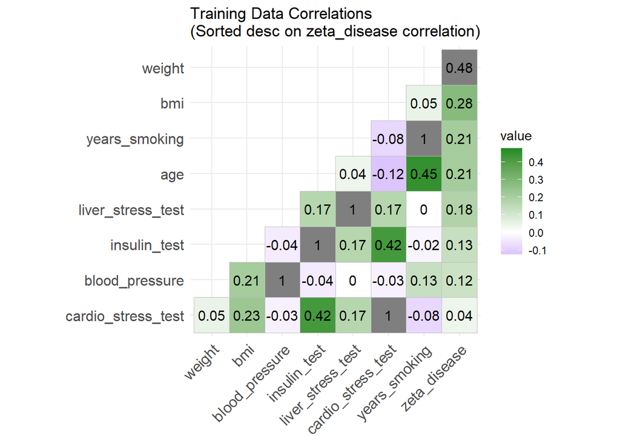

```r
#Now that I am done cleaning the training data, I am going to
#search for relationships in the data

cor_dat <- training_dat
# names(cor_dat) <- knitr:::escape_latex(names(cor_dat))

cors <- cor(cor_dat)
cors <- cors[,order(cors['zeta_disease',], decreasing = F)]
cor_plot <- ggcorrplot(cors,
                       # colors = c(min(cors), 0, max(cors[cors!=1])),
                       type = 'lower',
                       lab = T) +
  scale_fill_gradient2(limit = c(min(cors),max(cors[cors!=1])), low = "blue", high =  "forestgreen", mid = "white", midpoint = 0) +
  ggtitle('Training Data Correlations\n(Sorted desc on zeta_disease correlation)')

print(cor_plot)
```

```r
#Based on correlations alone, weight immediately sticks out as potentially predictive. Cardio stress test seems like it will be
#the least predictive


#Another angle I'd like to see on the data is average of each candidate predictor based on whether or not the person is
#zeta positive

#This shows an average profile of a zeta positive individual compared to a non zeta positive individual

zeta_means <- training_dat %>%
  group_by(zeta_disease) %>%
  summarise_all(mean) %>%
  left_join(training_dat %>% count(zeta_disease,name = 'Count')) %>%
  arrange(desc(zeta_disease))


#Chop off some decimal places
rnd <- function(x) round(x,2)

#mutate_all is a quick way to apply a function to every column in a dataframe
zeta_means <- mutate_all(zeta_means, rnd)

kable(zeta_means, format = 'latex') %>%
  kable_styling(bootstrap_options = "bordered",
                full_width = FALSE)
```

[output not shown]

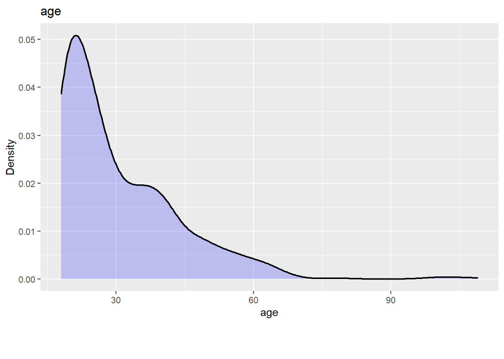

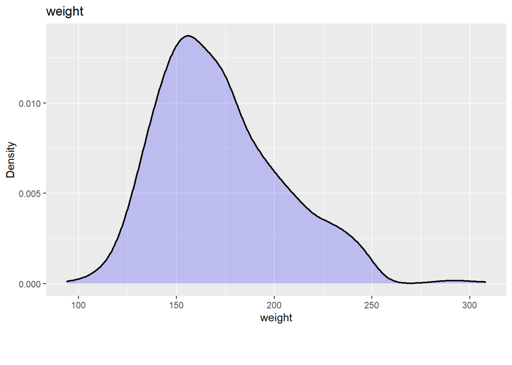

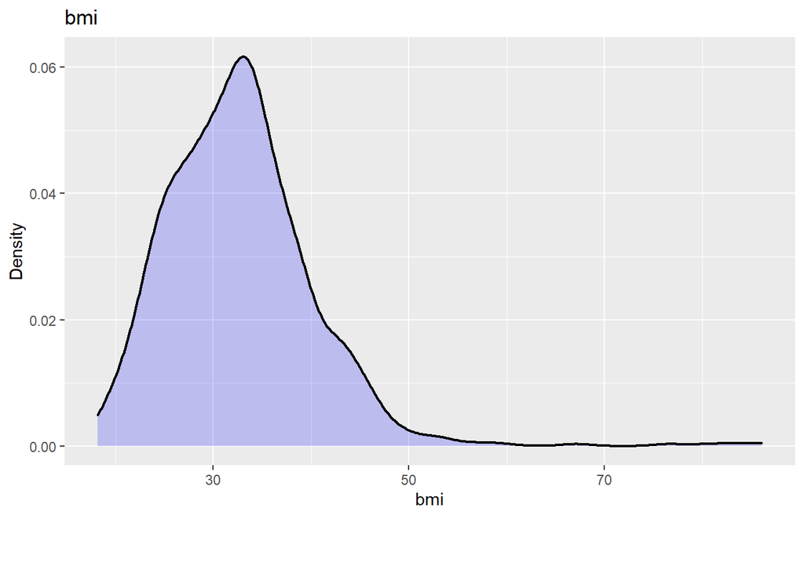

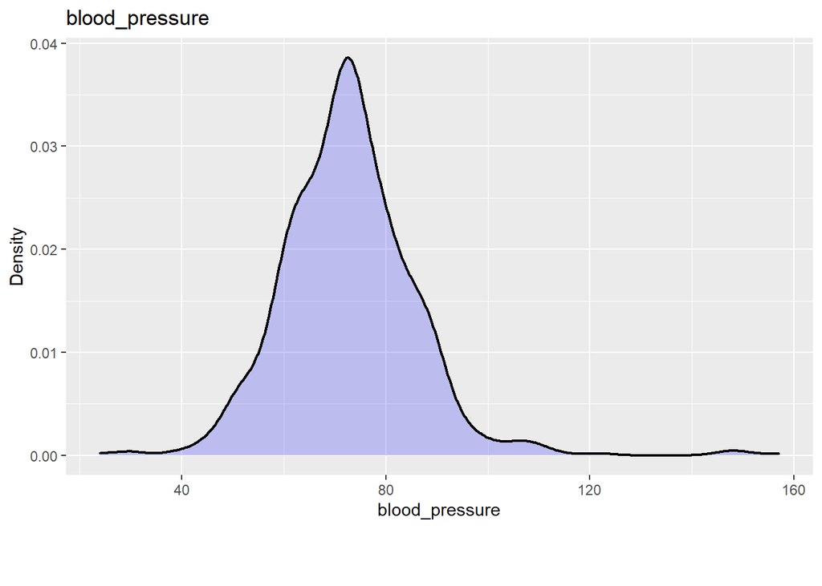

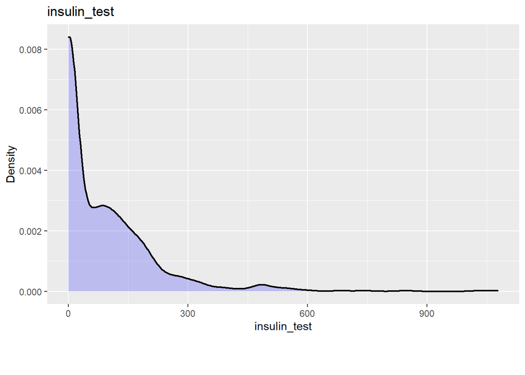

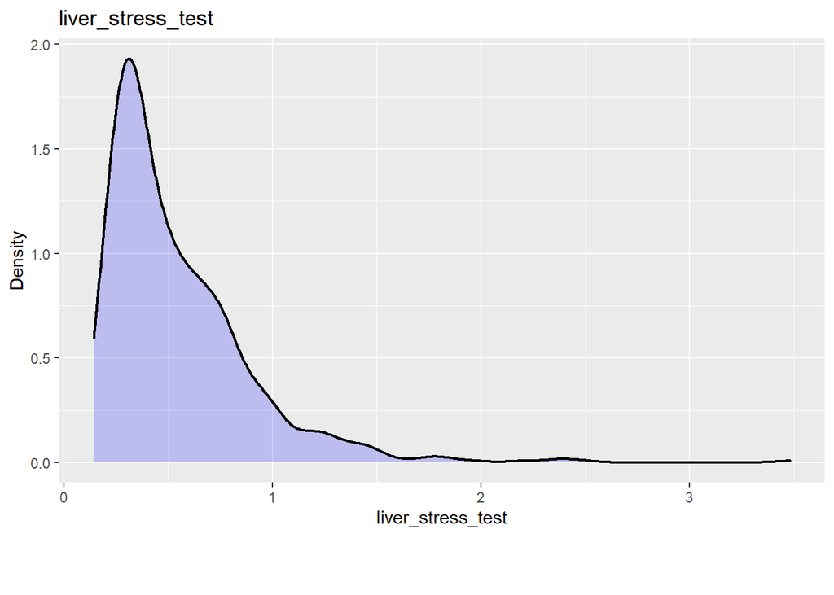

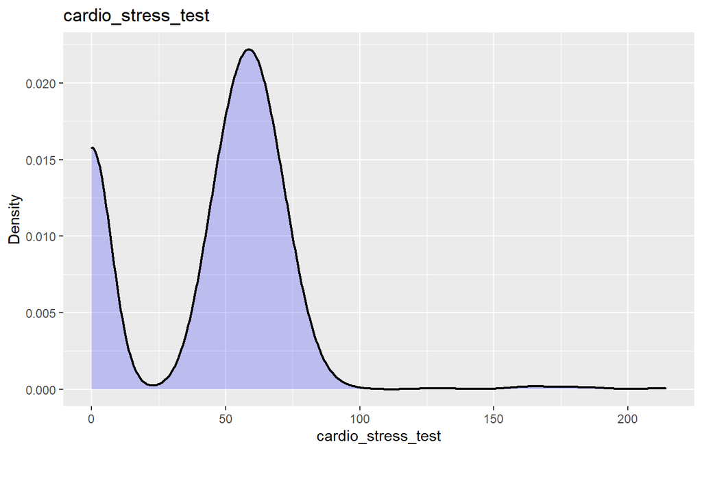

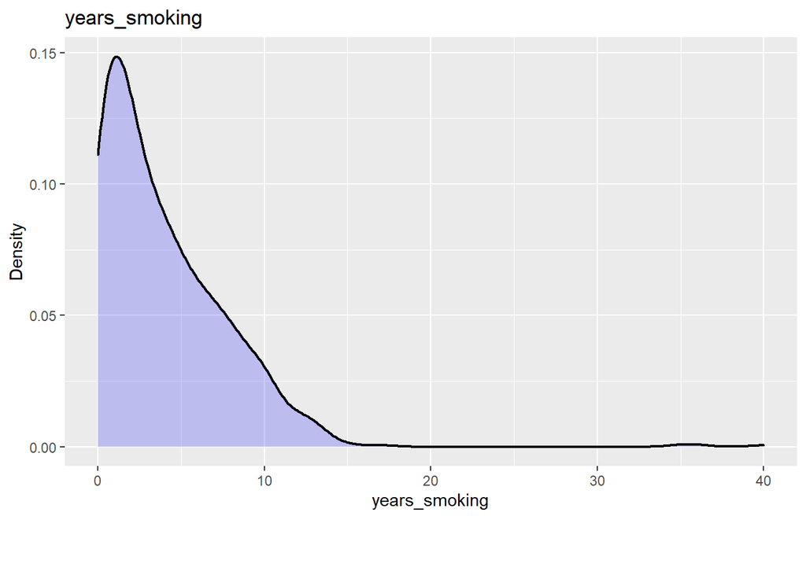

```r
#Want to also see how various candidate predictors are distributed

#Create function that takes dataframe and column name as input, and outputs density plot
plot_dense <- function(dat, col) {

  ggplot(dat, aes_string(x = col)) +
    geom_density(lwd = .8, fill = 'blue',alpha = .2) +
    ylab('Density') +
    ggtitle(c) +
    xlab(paste0(c, "\n\n\n"))


}

cols <- names(training_dat)[!names(training_dat) == 'zeta_disease']

for(c in cols) {

  p <- plot_dense(training_dat, c)
  print(p)
}
```

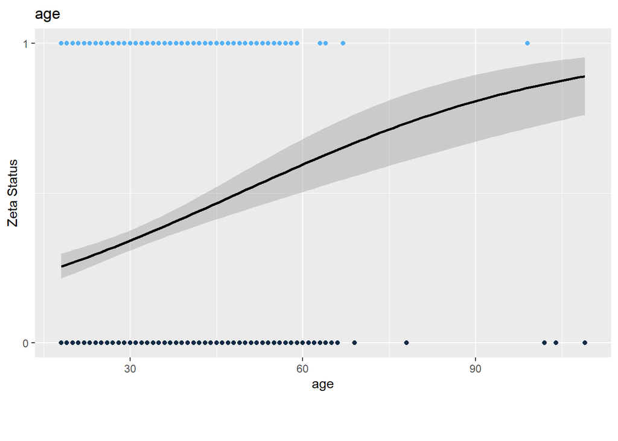

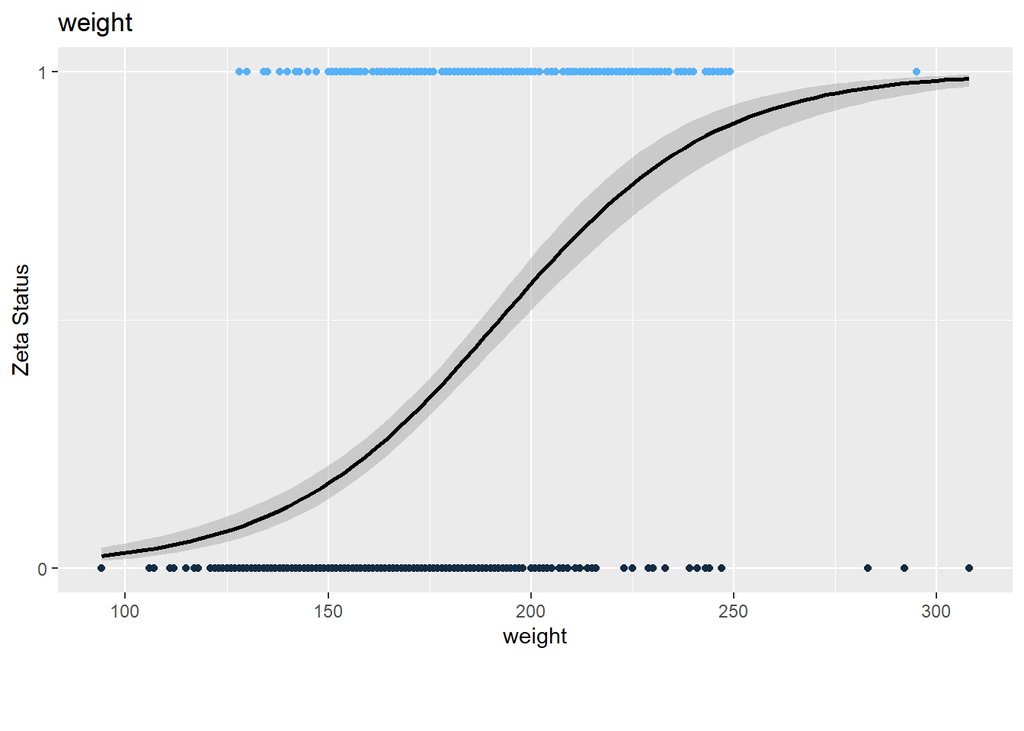

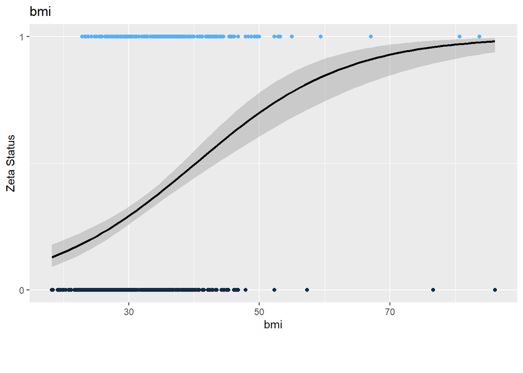

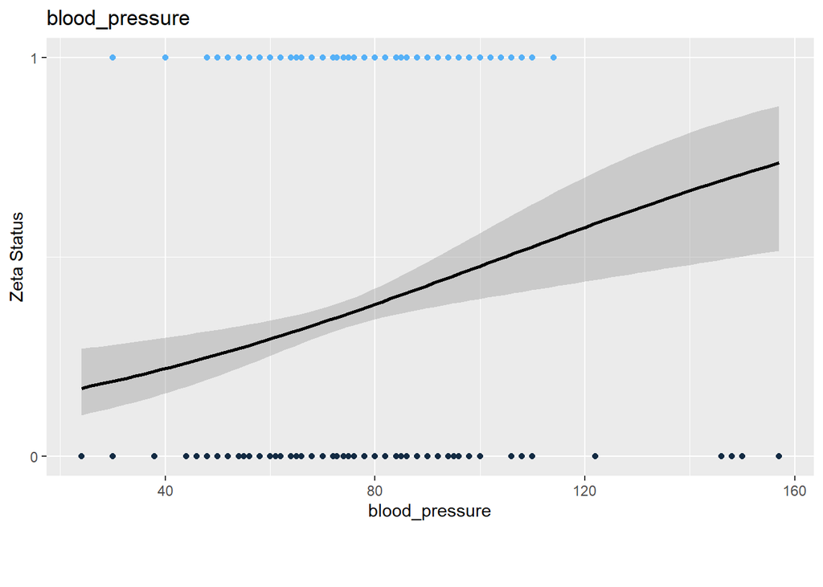

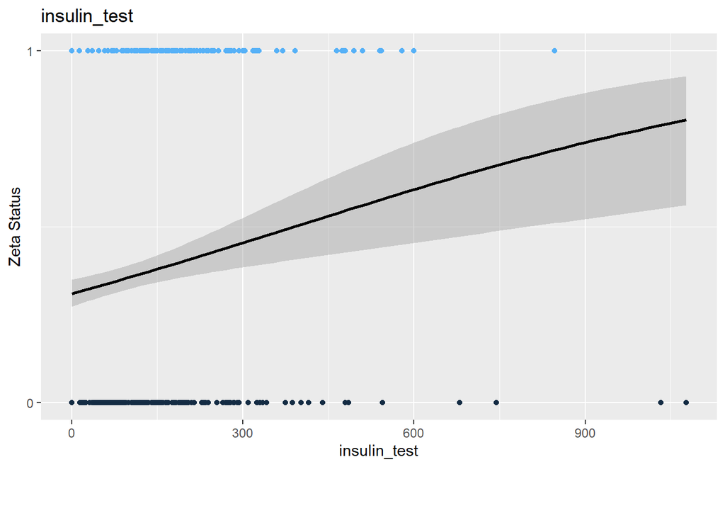

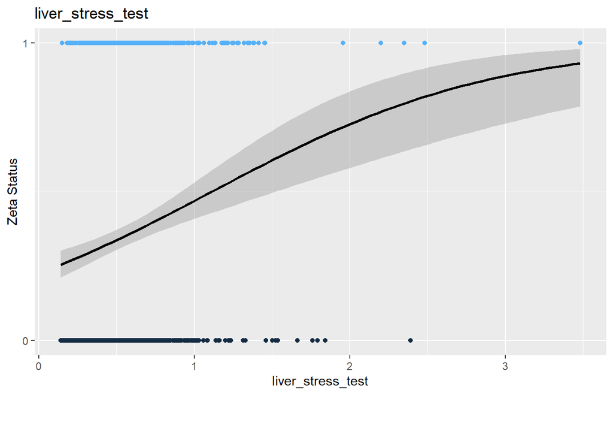

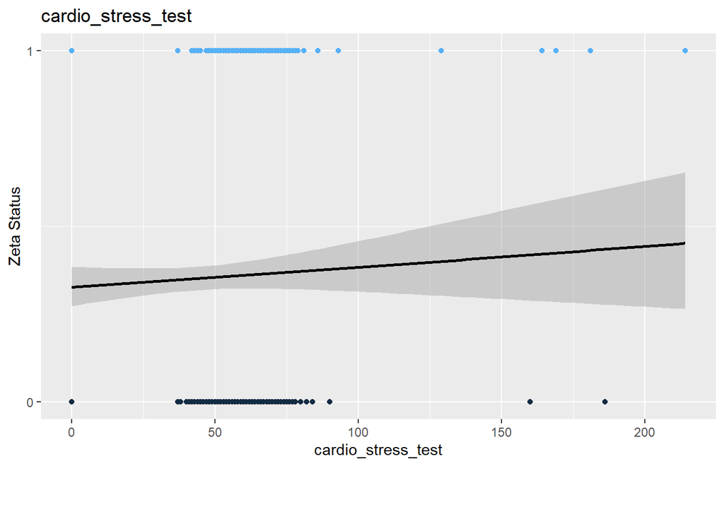

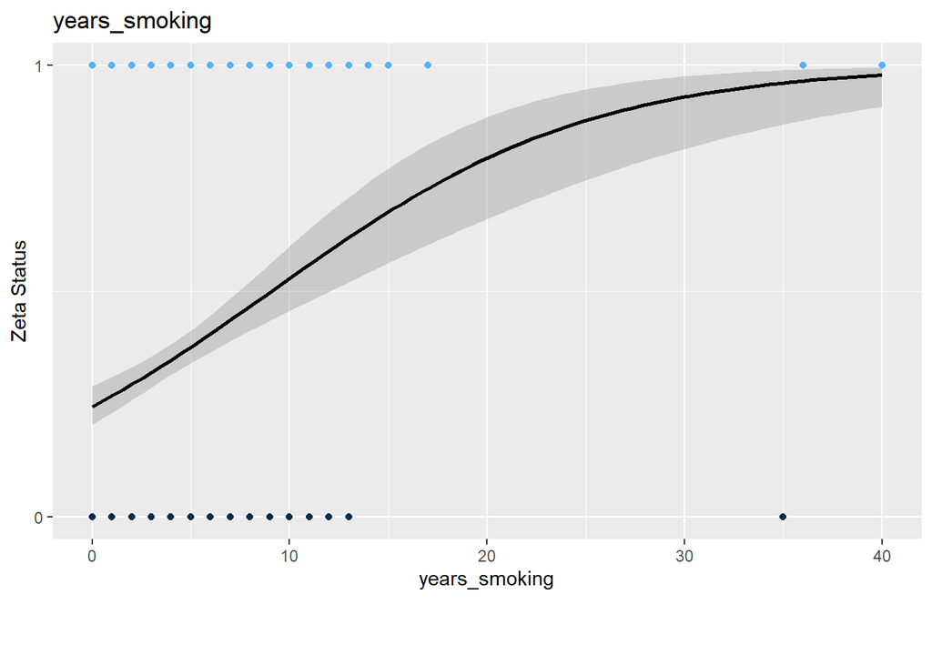

```r
#Also interested in seeing each variable plotted against zeta_disease in a scatterplot
#I will add a smoothing line to give some indicacator of the relationship between each
#variable and zeta_disease. It's important to note that outliers can have a major impact
#on the visual interpretation of the smoothing line, so a wider "shadow" around the line essentially
#indicates less trustworthiness in the shape of the line within that region of data.

#Create scatterplot function
plot_scatter <- function(dat1, dat2, col) {

  ggplot(dat1, aes_string(x = col, y = 'zeta_disease', color = 'zeta_disease')) +
    stat_smooth(method="glm", color="black", se=T,
                method.args = list(family=binomial)) +     geom_point() +
    # geom_vline(data = dat2, aes_string(xintercept = col, color = 'zeta_disease'), lwd = 1) +
    xlab(paste0(c, "\n\n\n")) +
    ggtitle(c) +
    scale_y_continuous(breaks = c(0,1)) +
    theme(legend.position = 'none') +
    ylab('Zeta Status')



}



for(c in cols) {

  p <- plot_scatter(training_dat, zeta_means, c)
  print(p)
}
```

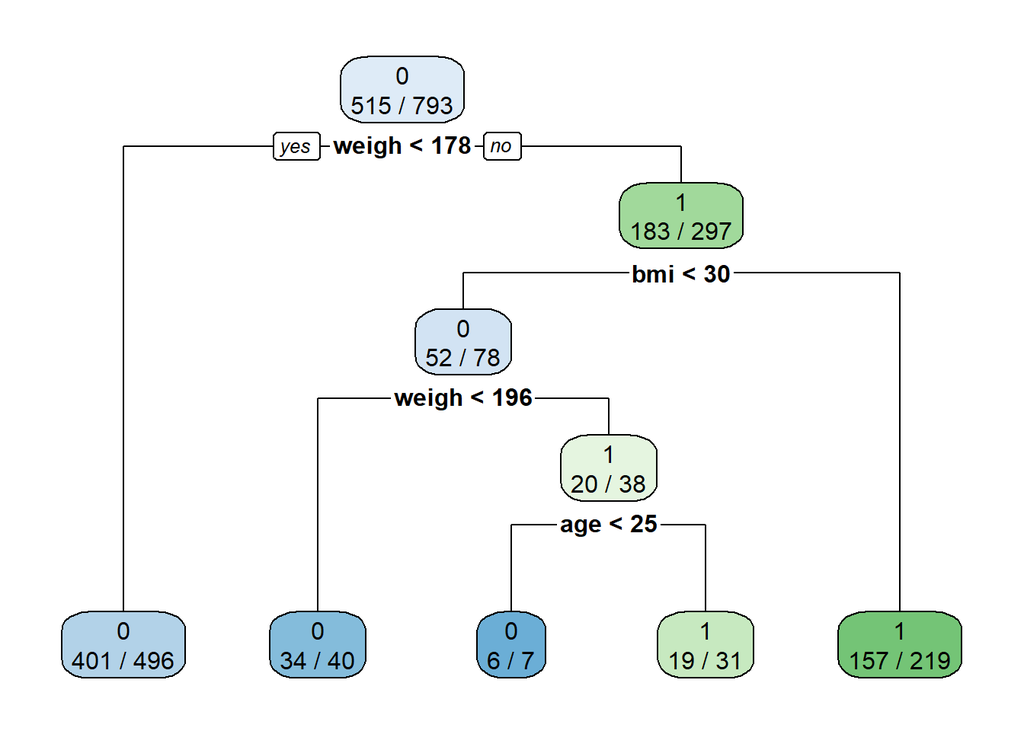

```r
#Tree------


#Another thing I want to see to get a very simple idea of how these features influence the outcome and interact with
#one another is a decision tree

#Indicate in training data that zeta_disease is categorical
training_dat <- mutate(training_dat, zeta_disease = as.factor(zeta_disease))

#I am going to shorten the variable names just so the plot prints tidier
tree_dat <- training_dat

shorten <- function(x) substr(x, 1,5)
names(tree_dat) <- sapply(names(tree_dat), shorten)

simple_tree <- rpart(zeta_ ~ ., data = tree_dat,
                     control = rpart.control(maxdepth = 4))

#Forcing the tree to make only 4 splits at most indicates that weight,
#BMI, and age will likely be important in a final model predicting zeta_disease

rpart.plot(simple_tree, cex = 1, extra = 2)
```

```r
#What I'm seeing in the tree corroborates some of what I was seeing in the correlation table and plot:
#weight as the root node and the field with the highest importance measure is consistent with it having
#the highest correlation with the target variable. cardio_stress_test seems to be inconsequential based on both
#correlation with the target as well as importance in the tree
```

```r
#Model----

#Now that I have cleaned the data and explored some of the relationships, I will
#build a few different classification models and select the one that is most successful


#The first thing I'm going to do is drop cardio_stress_test from the training data because it seems to be unimportant based
#on the preliminary analysis

training_dat <- select(training_dat, -cardio_stress_test)

#I also want to add a few features to the data. I could have
#added these in the data exploration step, but I wanted to avoid cluttering
#the rmarkdown document too much

# square <- function(x) x^2
#
# feature_funs <- list(sqrt = sqrt, square = square)


#mutate_at to target every variable that is not zeta_disease
#training_dat <- mutate_at(training_dat, vars(!matches('zeta_disease')), feature_funs)


#Actually, after creating features this way and running the models, I am seeing that they add nothing
#To the accuracy of any of the models, so I will comment out the prior couple lines of code

#Initialize h2o
h2o.init(nthreads = -1)
```

H2O is not running yet, starting it now…

Note: In case of errors look at the following log files: C:4caj41505915256f/h2o_willi_started_from_r.out C:4caj415015903f34/h2o_willi_started_from_r.err

Starting H2O JVM and connecting: Connection successful!

```r
#Hide progrses bar because it looks bad in rendered document
h2o.no_progress()

#Convert target variable to categorical to avoid accidentally predicting continuous outcome:
training_dat <- mutate(training_dat, zeta_disease = as.factor(zeta_disease))

#Convert training data to h2o object:
training_dat_h2o  <- as.h2o(training_dat)


#this line looks pointless but I had deleted a few lines of code
#where previously it made sense to have this here. Now I'm keeping it to avoid
#changing code below
train_h2o <- training_dat_h2o


#Want to run predictions on final test data as I go along
testing_dat_h2o <- predict_these %>%
  select(-zeta_disease) %>%
  as.h2o()

#character vector of candidate regressors:
candidate_regressors <- names(training_dat)[names(training_dat) != 'zeta_disease']

#target_variable
target <- 'zeta_disease'

#See all data types to make sure nothing accidentally ended up as categorical somehow (zeta_disease should show as factor here)
sapply(training_dat, class)
```

```
          age            weight               bmi    blood_pressure
    "integer"         "integer"         "numeric"         "numeric"
 insulin_test liver_stress_test     years_smoking      zeta_disease
    "integer"         "numeric"         "integer"          "factor"
```